# Analyze citation data from the crossref dataset

Ian Hussey

11 August, 2025

# TODO

- if covid/metas were excluded, these would need to be excluded from total citation counts too or the proportion of citations is underestimated.

# Data source

Data was taken from the March 2025 Public Data File from Crossref: https://academictorrents.com/details/e0eda0104902d61c025e27e4846b66491d4c9f98

The file is about 200GB so is too large to include the the public github, but can be freely downloaded from the torrent. Place the jsonl.gz files in the data/raw/ directory, there is no need to decompress them.

# Dependencies

```r
library(tidyverse)
library(scales)
library(janitor)
library(knitr)
library(kableExtra)
```

# Descriptive statistics

## Overall

```r
# check saved data loads
data_processed <- read_csv("../data/processed/data_processed_subset_shuffled.csv")

n_articles_meeting_citation_criterion <- data_processed |>
  count() |>
  pull(n)

data_logs <- read_csv("../data/processed/data_log.csv")

n_files_processed <- data_logs |>
  count() |>
  pull(n)

n_files_to_be_processed <- list.files(path = "../data/raw/", pattern = "\\.jsonl\\.gz$", full.names = TRUE) |>
  length()

n_articles_meeting_other_criteria <- data_logs |>
  summarize(total_n = sum(n_articles)) |>
  pull(total_n)

percent_articles_meeting_citation_criterion <- n_articles_meeting_citation_criterion / n_articles_meeting_other_criteria * 100
```

.jsonl files to be processed: 33402

.jsonl files processed: 33402

Articles in psych journals published after 2015: 645164

Articles meeting citations per year criterion: 2092

Percent of articles meeting the journals and year criteria that also met the 30 citations per year criterion: 0.32%

```r
citations_total <- data_logs |>
  summarize(citations_total = sum(citations_total)) |>
  pull(citations_total)

citations_articles_meeting_citation_criterion <- data_processed |>
  summarize(citations_sample = sum(citations)) |>
  pull(citations_sample)
```

Citations of all psych articles since 2015: 7809006

Citations of our subset of articles with 30+ citations per year: 719862

Percent of all citations made up by our subset: 9.2%

As such, our sample of just 0.32% of articles represented 9.2% of all citations.

## Subfield

```r
data_processed |>
  count(category) |>
  arrange(desc(n)) |>
  kable() |>
  kable_classic(full_width = FALSE)
```

| category | n |
| --- | --- |
| PSYCHOLOGY, EXPERIMENTAL | 362 |
| PSYCHOLOGY, MULTIDISCIPLINARY | 349 |
| PSYCHOLOGY, APPLIED | 305 |
| PSYCHOLOGY, CLINICAL | 286 |
| PSYCHOLOGY | 274 |
| PSYCHOLOGY, DEVELOPMENTAL | 253 |
| PSYCHOLOGY, SOCIAL | 174 |
| PSYCHOLOGY, EDUCATIONAL | 67 |
| PSYCHOLOGY, BIOLOGICAL | 11 |
| PSYCHOLOGY, MATHEMATICAL | 11 |

## Journal

```r
data_processed |>
  count(journal) |>
  arrange(desc(n)) |>
  kable() |>
  kable_classic(full_width = FALSE)
```

| journal | n |
| --- | --- |
| Computers in Human Behavior | 165 |
| Frontiers in Psychology | 110 |
| Nature Human Behaviour | 87 |
| Psychological Medicine | 56 |
| Journal of Management | 48 |
| Journal of Adolescent Health | 38 |
| Journal of Applied Psychology | 38 |
| Behavior Research Methods | 37 |
| Psychological Methods | 36 |
| Psychological Science | 31 |
| International Journal of Mental Health and Addiction | 30 |
| Journal of Personality and Social Psychology | 28 |
| Autism | 25 |
| European Child &amp; Adolescent Psychiatry | 23 |
| Journal of Autism and Developmental Disorders | 23 |
| Personality and Individual Differences | 23 |
| Organizational Research Methods | 22 |
| Psychology &amp; Marketing | 22 |
| Current Psychology | 21 |
| Developmental Cognitive Neuroscience | 21 |
| Journal of Organizational Behavior | 21 |
| Journal of the American Academy of Child &amp; Adolescent Psychiatry | 21 |
| Advances in Methods and Practices in Psychological Science | 20 |
| Child Abuse &amp; Neglect | 20 |
| Journal of Environmental Psychology | 19 |
| Depression and Anxiety | 17 |
| Journal of Anxiety Disorders | 16 |
| Journal of Vocational Behavior | 16 |
| Cyberpsychology, Behavior, and Social Networking | 15 |
| Frontiers in Human Neuroscience | 15 |

[output cut: 308 more lines]

# Gelman-and-King-esque plots

Gelman and King’s recommendation: “Publications with at least 250 citations”. However, our search strategy includes only returns articles that **also** meet the 30 citations per year since publication rule, so the preselection in the search may distort it. As such, the first plot is not a good choice for communication.

The second one is standardized by N all articles and N all citations in the full dataset, so is more appropriate.

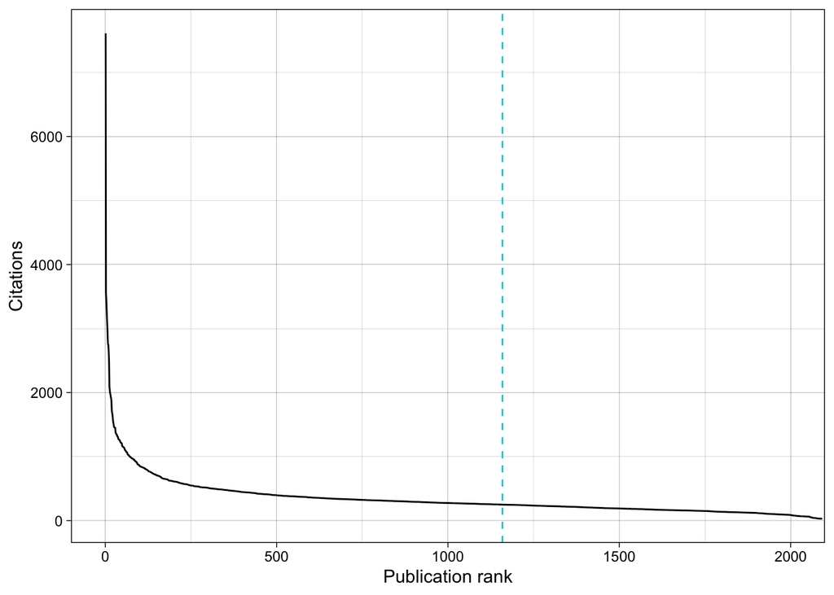

```r
data_ranks <- data_processed |>
  arrange(desc(citations)) |>
  mutate(citations_rank = row_number(),
         citations_rank_proportion = citations_rank/n_articles_meeting_other_criteria,
         citations_cumsum = cumsum(citations),
         citations_cumsum_proportion = citations_cumsum/citations_total) |>
  select(citations_rank, citations_rank_proportion, citations, citations_cumsum, citations_cumsum_proportion)

ggplot(data_ranks, aes(citations_rank, citations)) +
  geom_line() +
  geom_vline(xintercept = 1159, linetype = "dashed", color = "cyan3") + # from data_ranks where citations >= 250
  theme_linedraw() +
  ylab("Citations") +
  xlab("Publication rank") +
  coord_cartesian(xlim = c(0, 2000))
```

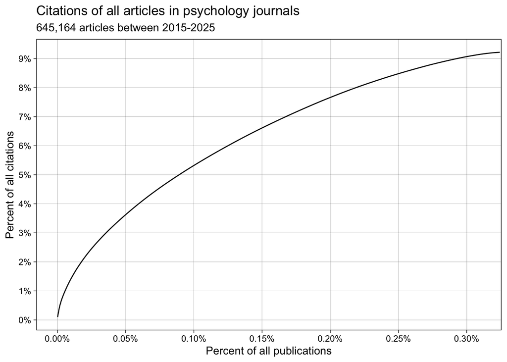

```r
ggplot(data_ranks, aes(citations_rank_proportion, citations_cumsum_proportion)) +
  geom_line() +
  scale_x_continuous(labels = label_percent(accuracy = 0.01),
                     breaks = breaks_pretty(n = 9),
                     name = "Percent of all publications") +
  scale_y_continuous(labels = label_percent(accuracy = 1),
                     breaks = breaks_pretty(n = 8),
                     name = "Percent of all citations") +
  coord_cartesian(xlim = c(0, 0.0031)) +
  theme_linedraw() +
  theme(panel.grid.minor.x = element_blank(),
        panel.grid.minor.y = element_blank()) +
  labs(title = "Citations of all articles in psychology journals",
       subtitle = "645,164 articles between 2015-2025")
```

```r
dir.create("plots")

ggsave("plots/citations_curve.png", width = 6, height = 4, dpi = 300)
```

# COVID studies and meta-analyses

## COVID in title

```r
data_processed |>
  summarize(percent_covid_in_title = round_half_up(mean(str_detect(title, regex("covid", ignore_case = TRUE)))*100, 1)) |>
  kable() |>
  kable_classic(full_width = FALSE)
```

| percent_covid_in_title |
| --- |
| 17.2 |

```r
data_processed |>
  filter(!str_detect(title, regex("covid", ignore_case = TRUE))) |>
  count(name = "n_without_covid")
```

```
## # A tibble: 1 × 1
##   n_without_covid
##             <int>
## 1            1732
```

## Meta in title

```r
data_processed |>
  summarize(percent_covid_in_title = round_half_up(mean(str_detect(title, regex("meta", ignore_case = TRUE)))*100, 1)) |>
  kable() |>
  kable_classic(full_width = FALSE)
```

| percent_covid_in_title |
| --- |
| 15.1 |

```r
data_processed |>
  filter(!str_detect(title, regex("meta", ignore_case = TRUE))) |>
  count(name = "n_without_covid")
```

```
## # A tibble: 1 × 1
##   n_without_covid
##             <int>
## 1            1776
```

## Meta in title excluding covid

```r
data_processed |>
  filter(!str_detect(title, regex("covid", ignore_case = TRUE))) |>
  summarize(percent_covid_in_title = round_half_up(mean(str_detect(title, regex("meta", ignore_case = TRUE)))*100, 1)) |>
  kable() |>
  kable_classic(full_width = FALSE)
```

| percent_covid_in_title |
| --- |
| 17.6 |

```r
data_processed |>
  filter(!str_detect(title, regex("covid", ignore_case = TRUE)) &
           !str_detect(title, regex("meta", ignore_case = TRUE))) |>
  count(name = "n_without_covid_or_meta")
```

```
## # A tibble: 1 × 1
##   n_without_covid_or_meta
##                     <int>
## 1                    1427
```